# ScRNAseq analysis

Integration analysis : nfeatures = 2000

juba

2025-08-03

# Import data

## Library 1

```
## An object of class Seurat
## 51653 features across 4874 samples within 3 assays
## Active assay: SCT (15050 features, 2000 variable features)
##  3 layers present: counts, data, scale.data
##  2 other assays present: RNA, HTO
##  2 dimensional reductions calculated: pca, umap
```

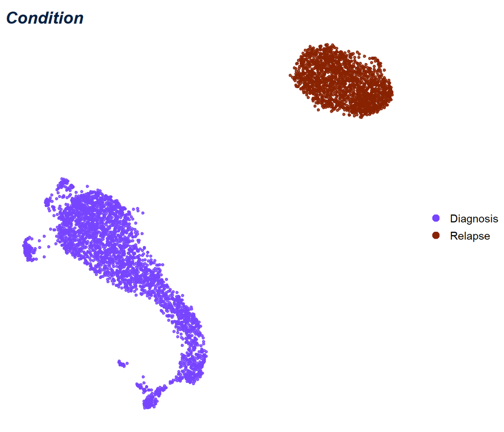

## Library 2

```
## An object of class Seurat
## 51279 features across 3771 samples within 3 assays
## Active assay: SCT (14676 features, 2000 variable features)
##  3 layers present: counts, data, scale.data
##  2 other assays present: RNA, HTO
##  2 dimensional reductions calculated: pca, umap
```

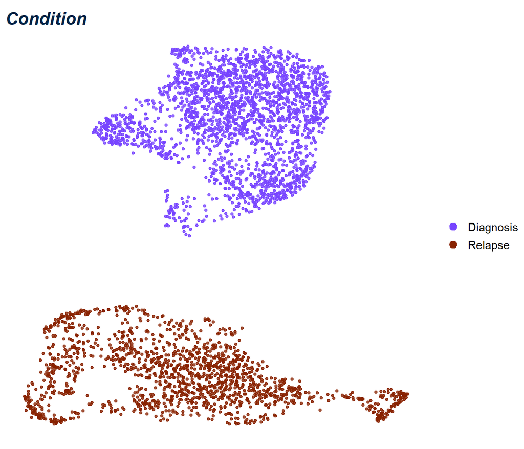

## Library 3

```
## An object of class Seurat
## 51215 features across 2377 samples within 3 assays
## Active assay: SCT (14612 features, 2000 variable features)
##  3 layers present: counts, data, scale.data
##  2 other assays present: RNA, HTO
##  2 dimensional reductions calculated: pca, umap
```

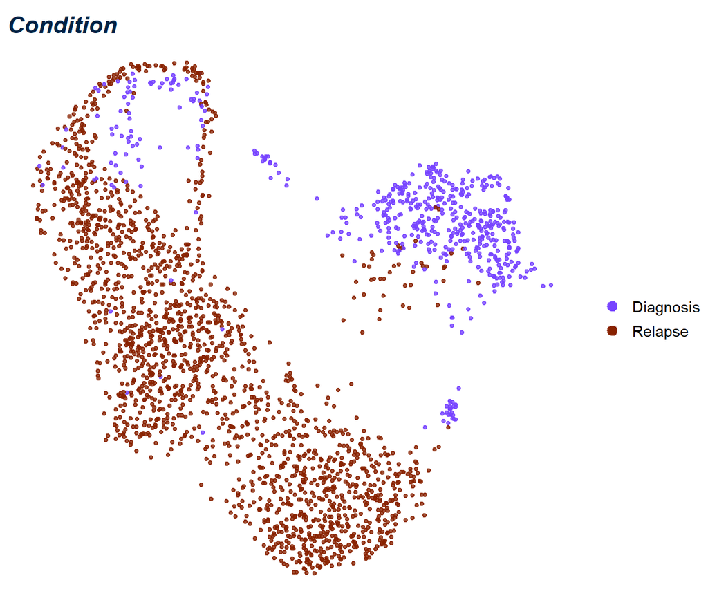

# Merging & Integration

In this section, we’re going to merge the 3 libraries and integrate them for batch effect correction.

But before the merging, we need to make some adjustments like renaming the cells for each library and selecting the metadata we are going to use.

1- Renaming the cells :

```r
sc1 <- RenameCells(sc1, new.names = paste0("Lib1_",Cells(sc1)))
sc2 <- RenameCells(sc2, new.names = paste0("Lib2_",Cells(sc2)))
sc3 <- RenameCells(sc3, new.names = paste0("Lib3_",Cells(sc3)))
```

2- Meta data selection :

```r
list_seurat <- list("Lib1" = sc1, "Lib2" = sc2, "Lib3" = sc3)

for(lib in names(list_seurat)){
  sc <- list_seurat[[lib]]

  sc@meta.data <- sc@meta.data %>%
    mutate(Lib = lib) %>%
    select(Lib, Condition, MyClusters, Clonotype, TCR, Phase)

  list_seurat[[lib]] <- sc
}
```

And now we have

- Library 1

```
## 'data.frame':    4874 obs. of  6 variables:
##  $ Lib       : chr  "Lib1" "Lib1" "Lib1" "Lib1" ...
##  $ Condition : chr  "Diagnosis" "Diagnosis" "Relapse" "Diagnosis" ...
##  $ MyClusters: chr  "D" "D" "R" "D" ...
##  $ Clonotype : chr  "missing" "missing" "cl1" "missing" ...
##  $ TCR       : chr  "missing" "missing" "TRBV5-4" "missing" ...
##  $ Phase     : chr  "G2M" "S" "G1" "G1" ...
```

- Library 2

```
## 'data.frame':    3771 obs. of  6 variables:
##  $ Lib       : chr  "Lib2" "Lib2" "Lib2" "Lib2" ...
##  $ Condition : chr  "Relapse" "Diagnosis" "Relapse" "Diagnosis" ...
##  $ MyClusters: chr  "R" "D" "R" "D" ...
##  $ Clonotype : chr  "cl1" "cl3" "cl2" "cl3" ...
##  $ TCR       : chr  "TRAV21" "TRBV12-3" "TRBV12-3" "TRBV12-3" ...
##  $ Phase     : chr  "G1" "G1" "G1" "G1" ...
```

- Library 3

```
## 'data.frame':    2377 obs. of  6 variables:
##  $ Lib       : chr  "Lib3" "Lib3" "Lib3" "Lib3" ...
##  $ Condition : chr  "Relapse" "Relapse" "Diagnosis" "Relapse" ...
##  $ MyClusters: chr  "R1" "R1" "D2" "R2" ...
##  $ Clonotype : chr  "cl2" "cl2" "cl1" "cl2" ...
##  $ TCR       : chr  "TRAV8-3" "TRAV8-3" "TRBV24-1" "TRAV8-3" ...
##  $ Phase     : chr  "G1" "G2M" "G2M" "G1" ...
```

# Merging without integrating

```r
DefaultAssay(sc_merged) <- "RNA"

sc_merged <- NormalizeData(sc_merged)
sc_merged <- FindVariableFeatures(sc_merged)
sc_merged <- ScaleData(sc_merged)
sc_merged <- RunPCA(sc_merged)
sc_merged <- FindNeighbors(sc_merged, dims = 1:30)
sc_merged <- FindClusters(sc_merged, resolution = seq(0.1, 0.7, by= 0.2))
```

```
## Modularity Optimizer version 1.3.0 by Ludo Waltman and Nees Jan van Eck
##
## Number of nodes: 11022
## Number of edges: 458720
##
## Running Louvain algorithm...
## Maximum modularity in 10 random starts: 0.9780
## Number of communities: 7
## Elapsed time: 1 seconds
## Modularity Optimizer version 1.3.0 by Ludo Waltman and Nees Jan van Eck
##
## Number of nodes: 11022
## Number of edges: 458720
##
## Running Louvain algorithm...
## Maximum modularity in 10 random starts: 0.9501
## Number of communities: 13
## Elapsed time: 1 seconds
## Modularity Optimizer version 1.3.0 by Ludo Waltman and Nees Jan van Eck
##
## Number of nodes: 11022
## Number of edges: 458720
##
## Running Louvain algorithm...
## Maximum modularity in 10 random starts: 0.9267
## Number of communities: 16
## Elapsed time: 0 seconds
## Modularity Optimizer version 1.3.0 by Ludo Waltman and Nees Jan van Eck
##
## Number of nodes: 11022
## Number of edges: 458720
##
## Running Louvain algorithm...
## Maximum modularity in 10 random starts: 0.9060
## Number of communities: 18
## Elapsed time: 1 seconds
```

```r
sc_merged <- RunUMAP(sc_merged, dims = 1:30)
```

## Results

- All the libraries

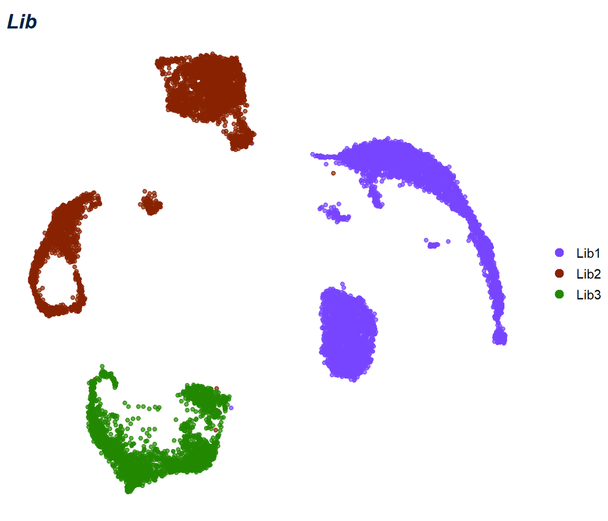

- Clusters and conditions

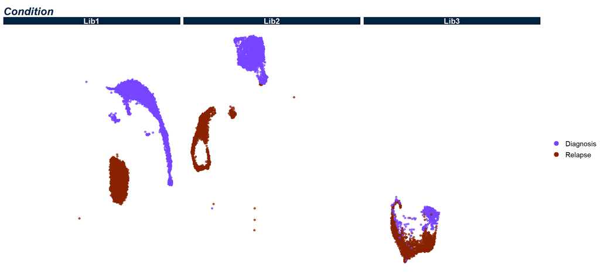

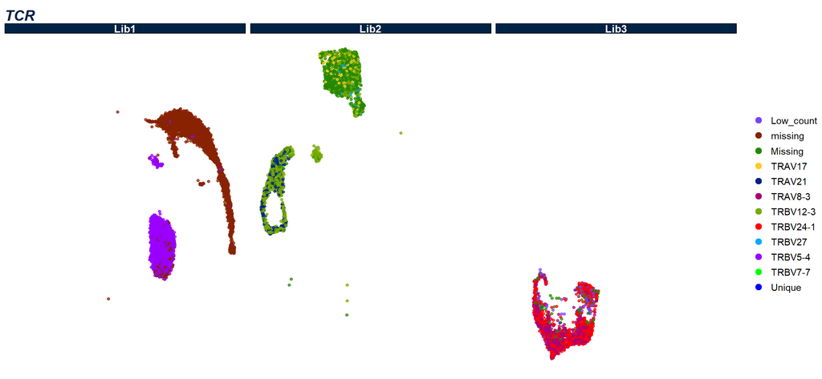

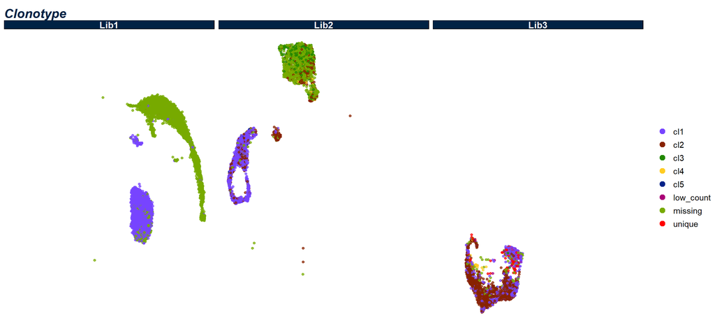

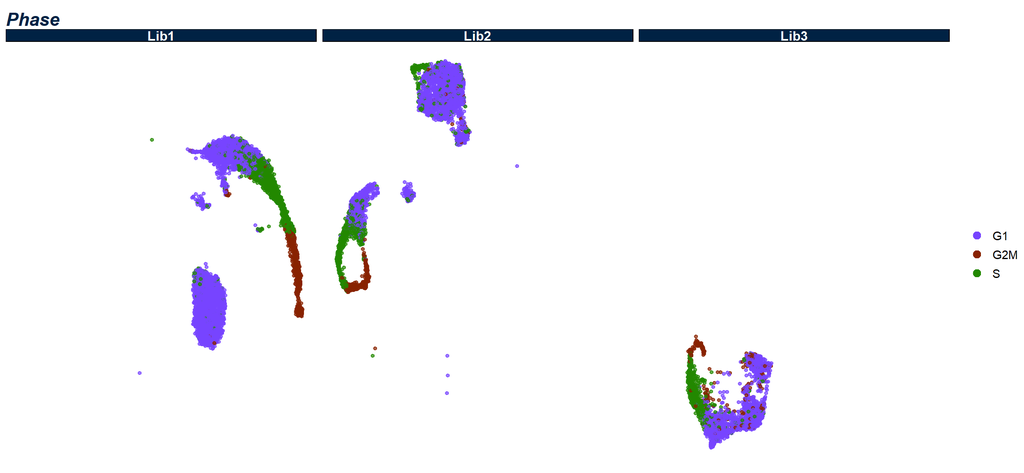

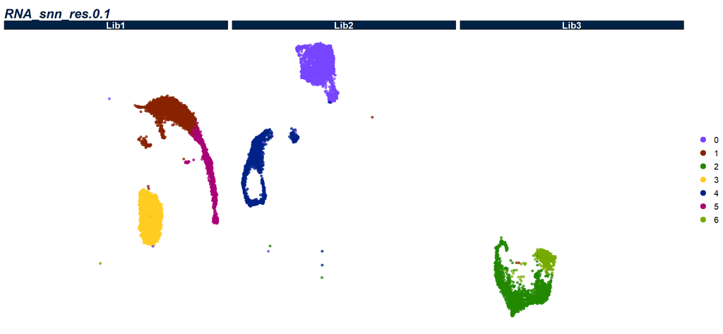

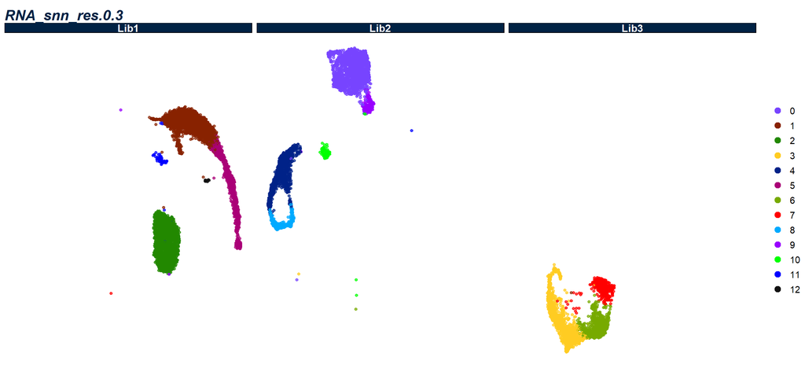

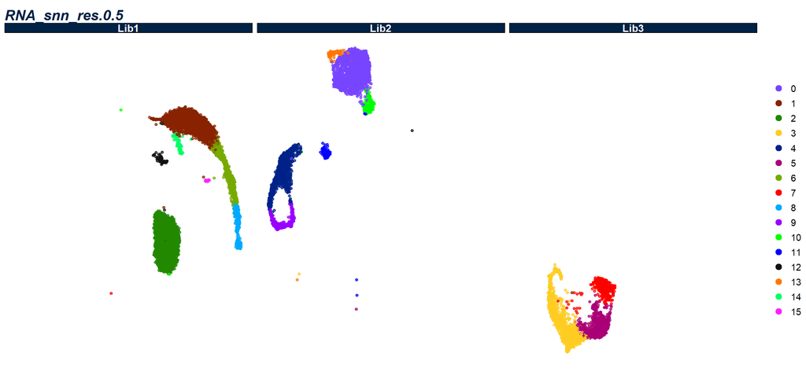

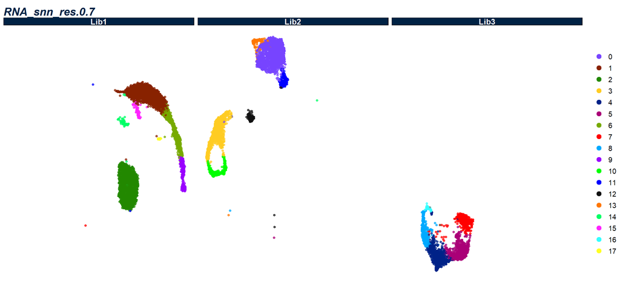

# SCT-based integration

To enable meaningful comparisons across patients and experimental conditions, we perform an integration using Seurat’s SCT-based workflow. This approach allows us to align transcriptomic profiles across libraries by minimizing batch effects and technical variation.

SCT-based integration places cells from different samples into a shared expression space, facilitating: - Global clustering across all cells, regardless of origin, - Detection of shared or unique cell states across patients or conditions, - Robust differential expression analysis between matched biological conditions, - More interpretable and comparable UMAP representations.

Integration ensures that downstream results reflect biological rather than technical differences.

We’ll be merging & integrating using SCT pipeline :

1- Selecting the features for Integration

```r
features <- SelectIntegrationFeatures(object.list = list(sc1, sc2, sc3),
                                      nfeatures = params$IntegrationFeatures)
```

We select the top **2000** highly variable genes that are shared across all samples.

These genes serve as common anchors to align datasets during integration, ensuring that biological signal is preserved while correcting for technical variation.

2- Preparing for SCT Integration

```r
sc <- list(sc1, sc2, sc3)
sc <- PrepSCTIntegration(object.list = sc,
                         anchor.features = features)
```

This step prepares each object for integration by scaling and aligning the selected features across datasets.

This ensures all objects are comparable before identifying anchors, without altering the original data.

3- Find Integration Anchors

```r
anchors <- FindIntegrationAnchors(object.list = sc,
                                  normalization.method = "SCT",
                                  anchor.features = features)
```

Identifies anchors—pairs of biologically similar cells across datasets that will be used to align and integrate the data.

These anchors form the basis for correcting technical variation while preserving shared biological structure.

4- Integrating the data

```r
SeuratObj <- IntegrateData(anchorset = anchors,
                           normalization.method = "SCT")
```

Integrates all datasets into a single Seurat object using the identified anchors.

The resulting “integrated” assay contains batch-corrected expression values suitable for downstream analysis.

5- Clustering

```r
SeuratObj <- RunPCA(SeuratObj)
SeuratObj <- RunUMAP(SeuratObj, dims = 1:30)
SeuratObj <- FindNeighbors(SeuratObj, dims = 1:30)
SeuratObj <- FindClusters(SeuratObj, resolution = seq(0.1, 1.1, 0.2))
```

Principal Component Analysis (PCA) and Uniform Manifold Approximation (UMAP) are performed on the integrated data.

We then compute a nearest-neighbor graph and apply clustering across multiple resolutions to explore cellular heterogeneity.

## Data exploration

Let’s explore the data now !

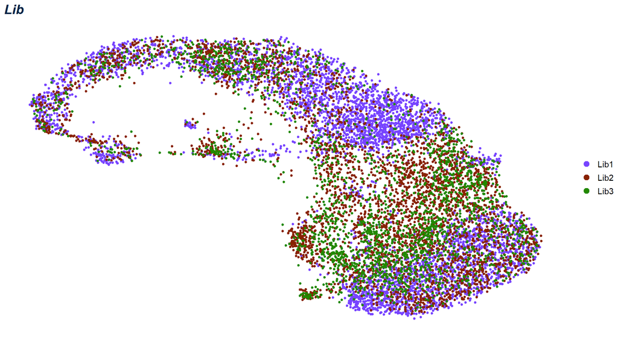

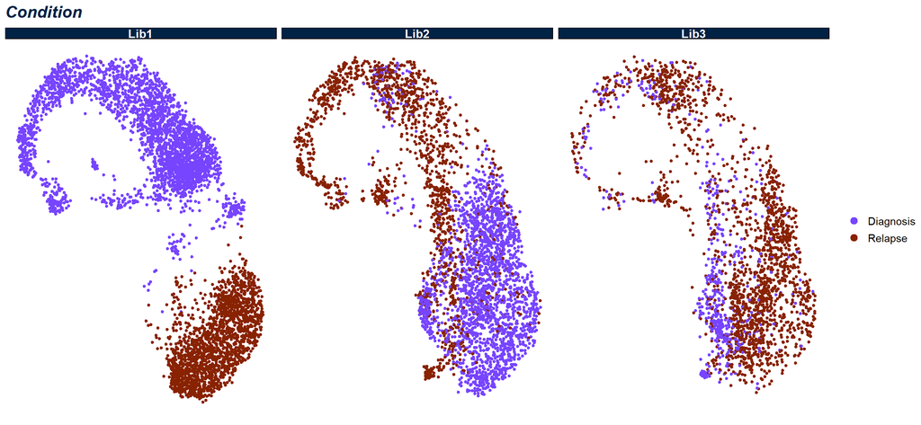

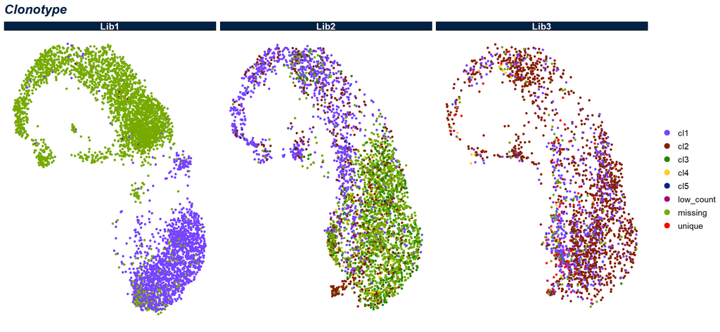

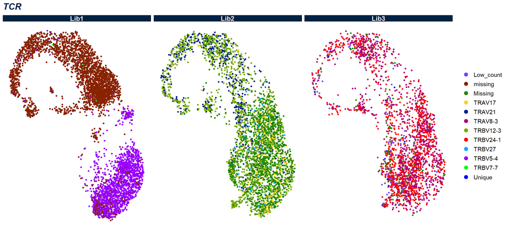

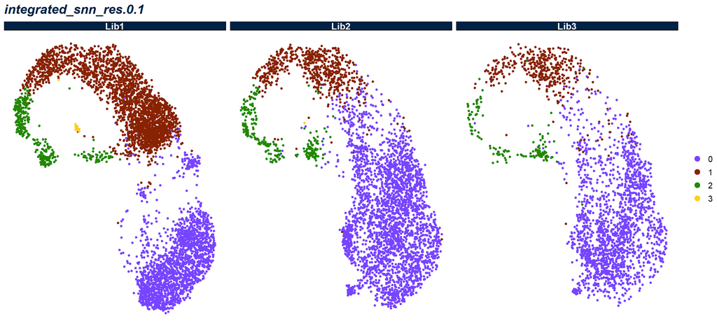

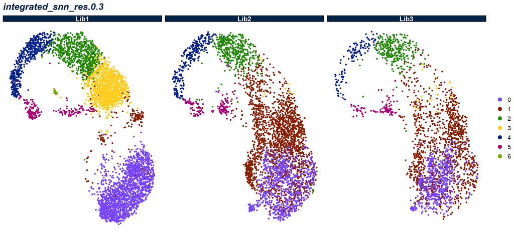

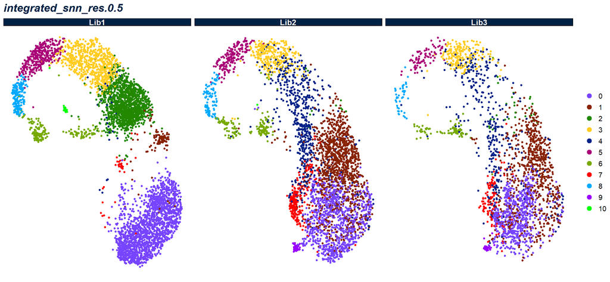

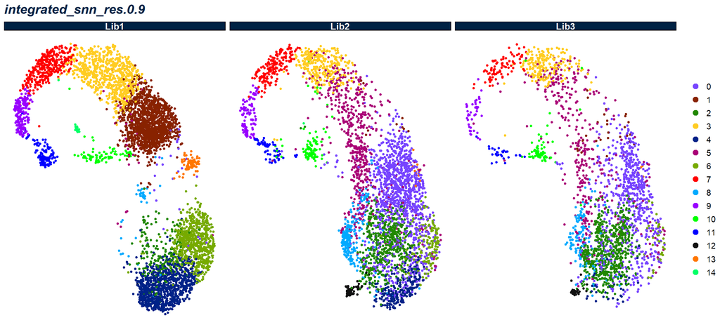

## Differential Expression Analysis (DEA)

Now we can proceed to the DEA between **Relapse** and **Diagnosis** across the 3 patients to find the common DEGs

[output not shown]

[output cut: 114 more lines]